# KNN Classification

Hajin Jang

10/1/2025

## KNN Classification

```r
library(ISLR2)
library(FNN)
library(caret)
library(tidyverse)
head(Carseats)
```

```
##   Sales CompPrice Income Advertising Population Price ShelveLoc Age Education
## 1  9.50       138     73          11        276   120       Bad  42        17
## 2 11.22       111     48          16        260    83      Good  65        10
## 3 10.06       113     35          10        269    80    Medium  59        12
## 4  7.40       117    100           4        466    97    Medium  55        14
## 5  4.15       141     64           3        340   128       Bad  38        13
## 6 10.81       124    113          13        501    72       Bad  78        16
##   Urban  US
## 1   Yes Yes
## 2   Yes Yes
## 3   Yes Yes
## 4   Yes Yes
## 5   Yes  No
## 6    No Yes
```

#### Training and validation sets (70%/30%)

```r
set.seed(0911)
train <- sample(1:nrow(Carseats), size=ceiling(nrow(Carseats)*.7))
```

```r
str(train)
```

```
##  int [1:280] 302 195 334 141 191 17 178 311 376 233 ...
```

```r
length(train)
```

```
## [1] 280
```

```r
train[1:10]
```

```
##  [1] 302 195 334 141 191  17 178 311 376 233
```

```r
length(train)/nrow(Carseats)
```

```
## [1] 0.7
```

#### Preprocessing

##### One-hot coding

```r
Carseats.xmat <- model.matrix(ShelveLoc~., data=Carseats[,-c(2:5, 8:9)])
str(Carseats.xmat)
```

```
##  num [1:400, 1:5] 1 1 1 1 1 1 1 1 1 1 ...
##  - attr(*, "dimnames")=List of 2
##   ..$ : chr [1:400] "1" "2" "3" "4" ...
##   ..$ : chr [1:5] "(Intercept)" "Sales" "Price" "UrbanYes" ...
##  - attr(*, "assign")= int [1:5] 0 1 2 3 4
##  - attr(*, "contrasts")=List of 2
##   ..$ Urban: chr "contr.treatment"
##   ..$ US   : chr "contr.treatment"
```

```r
Carseats.xmat[1:10,]
```

```
##    (Intercept) Sales Price UrbanYes USYes
## 1            1  9.50   120        1     1
## 2            1 11.22    83        1     1
## 3            1 10.06    80        1     1
## 4            1  7.40    97        1     1
## 5            1  4.15   128        1     0
## 6            1 10.81    72        0     1
## 7            1  6.63   108        1     0
## 8            1 11.85   120        1     1
## 9            1  6.54   124        0     0
## 10           1  4.69   124        0     1
```

```r
Carseats.xmat <- Carseats.xmat[,-1]
```

##### Standardization

```r
Carseats.xmat[1:10,]
```

```
##    Sales Price UrbanYes USYes
## 1   9.50   120        1     1
## 2  11.22    83        1     1
## 3  10.06    80        1     1
## 4   7.40    97        1     1
## 5   4.15   128        1     0
## 6  10.81    72        0     1
## 7   6.63   108        1     0
## 8  11.85   120        1     1
## 9   6.54   124        0     0
## 10  4.69   124        0     1
```

```r
Carseats.XConTr <- Carseats.xmat[train,1:2]
Carseats.XCatTr <- Carseats.xmat[train,3:4]
```

```r
preProcVals<- preProcess(Carseats.XConTr, method=c("center", "scale"))
str(preProcVals)
```

```
## List of 21
##  $ dim              : int [1:2] 280 2
##  $ bc               : NULL
##  $ yj               : NULL
##  $ et               : NULL
##  $ invHyperbolicSine: NULL
##  $ mean             : Named num [1:2] 7.47 116.08
##   ..- attr(*, "names")= chr [1:2] "Sales" "Price"
##  $ std              : Named num [1:2] 2.85 23.86
##   ..- attr(*, "names")= chr [1:2] "Sales" "Price"
##  $ ranges           : NULL
##  $ rotation         : NULL
##  $ method           :List of 3
##   ..$ center: chr [1:2] "Sales" "Price"
##   ..$ scale : chr [1:2] "Sales" "Price"
##   ..$ ignore: chr(0)
##  $ thresh           : num 0.95
##  $ pcaComp          : NULL
##  $ numComp          : NULL
##  $ ica              : NULL
##  $ wildcards        :List of 2
##   ..$ PCA: chr(0)
##   ..$ ICA: chr(0)
##  $ k                : num 5
##  $ knnSummary       :function (x, ...)
##  $ bagImp           : NULL
##  $ median           : NULL
##  $ data             : NULL
##  $ rangeBounds      : num [1:2] 0 1
##  - attr(*, "class")= chr "preProcess"
```

```r
Carseats.XConTrZ <- predict(preProcVals, Carseats.XConTr)
Carseats.XTrZ <- cbind(Carseats.XConTrZ, Carseats.XCatTr)
```

```r
dim(Carseats.XTrZ)
```

```
## [1] 280   4
```

```r
Carseats.XTrZ[1:5,]
```

```
##           Sales      Price UrbanYes USYes
## 302 -0.02170428 -1.2188787        1     1
## 195 -0.08489872  0.4997073        1     1
## 334 -0.56236783  1.2961252        1     1
## 141 -0.50619499  0.5416241        1     1
## 191  0.46278643 -0.6320444        0     1
```

```r
summary(Carseats.XTrZ)
```

```
##      Sales              Price             UrbanYes          USYes
##  Min.   :-2.62321   Min.   :-3.85963   Min.   :0.0000   Min.   :0.0000
##  1st Qu.:-0.69402   1st Qu.:-0.68444   1st Qu.:0.0000   1st Qu.:0.0000
##  Median :-0.01819   Median : 0.03862   Median :1.0000   Median :1.0000
##  Mean   : 0.00000   Mean   : 0.00000   Mean   :0.7286   Mean   :0.6536
##  3rd Qu.: 0.65061   3rd Qu.: 0.58354   3rd Qu.:1.0000   3rd Qu.:1.0000
##  Max.   : 3.08887   Max.   : 3.14046   Max.   :1.0000   Max.   :1.0000
```

##### Validation set

```r
Carseats.XConVal <- Carseats.xmat[-train,1:2]
Carseats.XCatVal <- Carseats.xmat[-train,3:4]
Carseats.XConValZ <- predict(preProcVals, Carseats.XConVal)
Carseats.XValZ <- cbind(Carseats.XConValZ, Carseats.XCatVal)
dim(Carseats.XValZ)
```

```
## [1] 120   4
```

```r
Carseats.XValZ[1:5,]
```

```
##         Sales      Price UrbanYes USYes
## 3   0.9086583 -1.5122958        1     1
## 7  -0.2955469 -0.3386273        1     0
## 18  1.6915672  0.6254575        1     1
## 20  0.4417216  0.2062902        1     1
## 21 -0.3727845  0.6254575        1     1
```

```r
summary(Carseats.XValZ)
```

```
##      Sales              Price             UrbanYes        USYes
##  Min.   :-1.98424   Min.   :-2.64405   Min.   :0.00   Min.   :0.000
##  1st Qu.:-0.78355   1st Qu.:-0.63204   1st Qu.:0.00   1st Qu.:0.000
##  Median : 0.05729   Median : 0.14342   Median :1.00   Median :1.000
##  Mean   : 0.02868   Mean   :-0.03962   Mean   :0.65   Mean   :0.625
##  3rd Qu.: 0.62779   3rd Qu.: 0.63594   3rd Qu.:1.00   3rd Qu.:1.000
##  Max.   : 2.60789   Max.   : 2.30213   Max.   :1.00   Max.   :1.000
```

##### Update Y vector

```r
Carseats.YTr <- Carseats$ShelveLoc[train]
Carseats.YVal <- Carseats$ShelveLoc[-train]
```

#### Performing KNN regression

```r
mKnnClass <- function(trainDat, validDat, trainOut, validOut, k){
 confKNN <- list(NA, times=length(k))
 accKNN <- rep(NA, times=length(k))
 for (i in 1:length(k)) {
 out <- knn(train=trainDat, test=validDat, cl=trainOut, k=k[i])
 confKNN[[i]] <- confusionMatrix(out, validOut)
 accKNN[i] <- confKNN[[i]]$overall[1]
 }
 return(list(conf=confKNN, accuracy=accKNN))
}

Kvec <- 1:20

confKNN <- mKnnClass(trainDat=Carseats.XTrZ, validDat=Carseats.XValZ, trainOut=Carseats.YTr, validOut=Carseats.YVal, k=Kvec)

str(confKNN[[2]])
```

```
##  num [1:20] 0.45 0.408 0.492 0.508 0.533 ...
```

#### Plotting K vs. misclassification (1-accuracy)

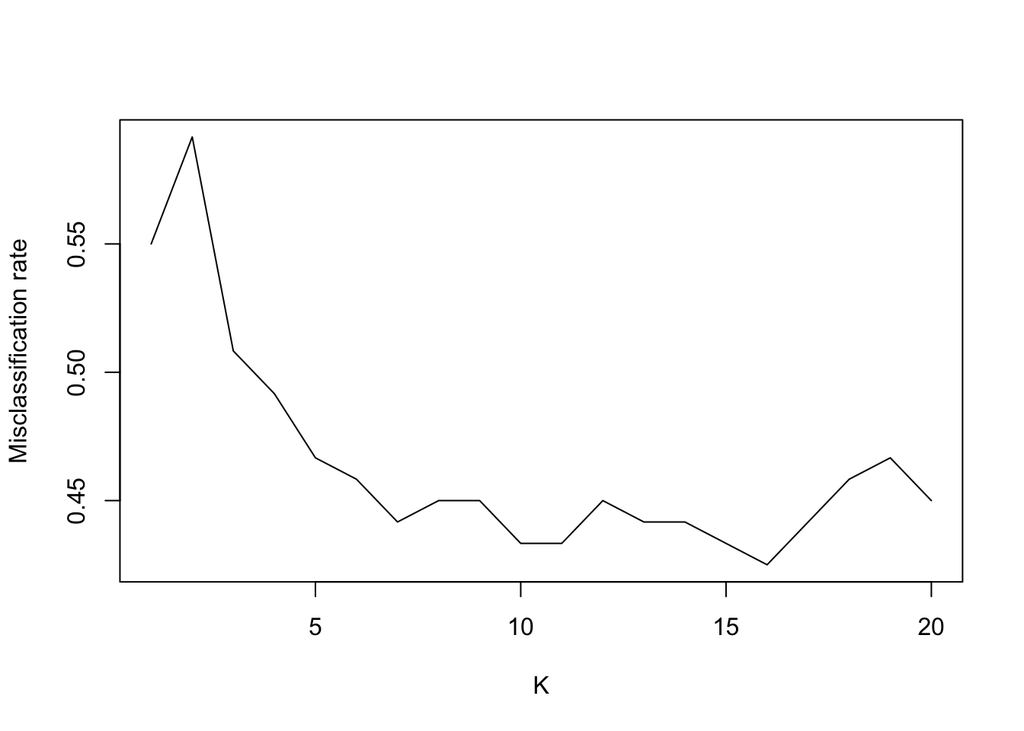

```r
acc <- confKNN[[2]]
misclass <- 1-acc

plot(Kvec, misclass, type="l", xlab="K", ylab="Misclassification rate", xlim=c(min(Kvec), max(Kvec)))
```

```r
kopt <- which.max(confKNN[[2]])
kopt
```

```
## [1] 16
```

```r
confKNNopt <- mKnnClass(trainDat=Carseats.XTrZ, validDat=Carseats.XValZ, trainOut=Carseats.YTr, validOut=Carseats.YVal, k=kopt)

outFinal <- knn(train=Carseats.XTrZ, test=Carseats.XValZ, cl=Carseats.YTr, k=kopt)

confKNNopt[[1]]
```

```
## [[1]]
## Confusion Matrix and Statistics
##
##           Reference
## Prediction Bad Good Medium
##     Bad      6    0      5
##     Good     0    9      8
##     Medium  23   15     54
##
## Overall Statistics
##
##                Accuracy : 0.575
##                  95% CI : (0.4815, 0.6647)
##     No Information Rate : 0.5583
##     P-Value [Acc > NIR] : 0.3927
##
##                   Kappa : 0.185
##
##  Mcnemar's Test P-Value : NA
##
## Statistics by Class:
##
##                      Class: Bad Class: Good Class: Medium
## Sensitivity             0.20690      0.3750        0.8060
## Specificity             0.94505      0.9167        0.2830
## Pos Pred Value          0.54545      0.5294        0.5870
## Neg Pred Value          0.78899      0.8544        0.5357
## Prevalence              0.24167      0.2000        0.5583
## Detection Rate          0.05000      0.0750        0.4500
## Detection Prevalence    0.09167      0.1417        0.7667
## Balanced Accuracy       0.57598      0.6458        0.5445
##
## $times
## [1] 1
```

```r
confKNNopt[[2]]
```

```
## [1] 0.575
```

#### Interpretation

##### Sales

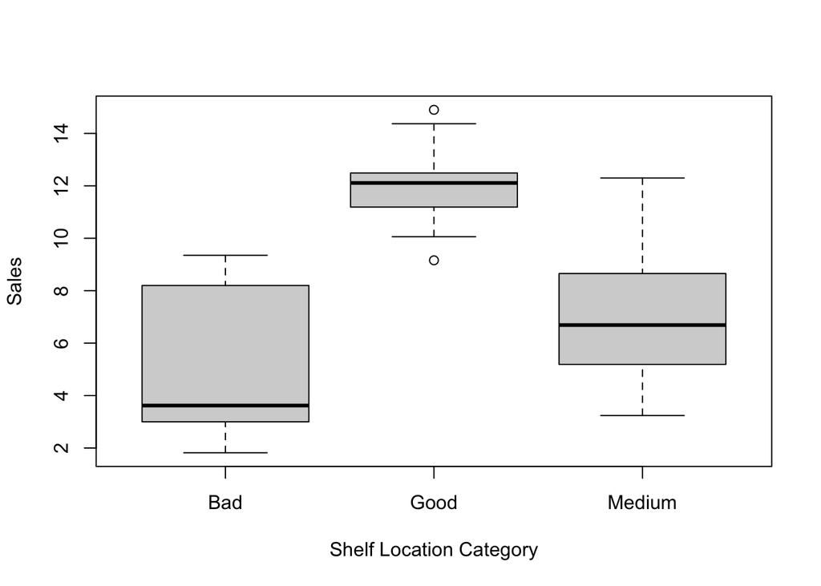

```r
plotdat <- data.frame(Sales=Carseats$Sales[-train], Price=Carseats$Price[-train], Urban=Carseats$Urban[-train], US=Carseats$US[-train], PredShelveLocCat=outFinal)

boxplot(plotdat$Sales~plotdat$PredShelveLocCat, xlab="Shelf Location Category", ylab="Sales")
```

Bad shelf location: Sales span from roughly 2 to 10, with a median near 4. The distribution is highly variable but tends to be lower overall compared with other shelf placements.

Good shelf location: Sales fall between about 9 and 14, with a median close to 12. This indicates that products in “Good” shelf spots are more likely to achieve higher sales, and the lower variability suggests more consistent performance.

Medium shelf location: Sales range from 4 to 12, with a median around 7. Variability is moderate, and performance lies between that of the “Bad” and “Good” shelf placements in both range and median.

Overall pattern: Higher sales are generally linked to “Good” shelf locations, lower sales to “Bad” locations, and “Medium” shelves occupy the middle ground in terms of sales levels and consistency.

##### Price

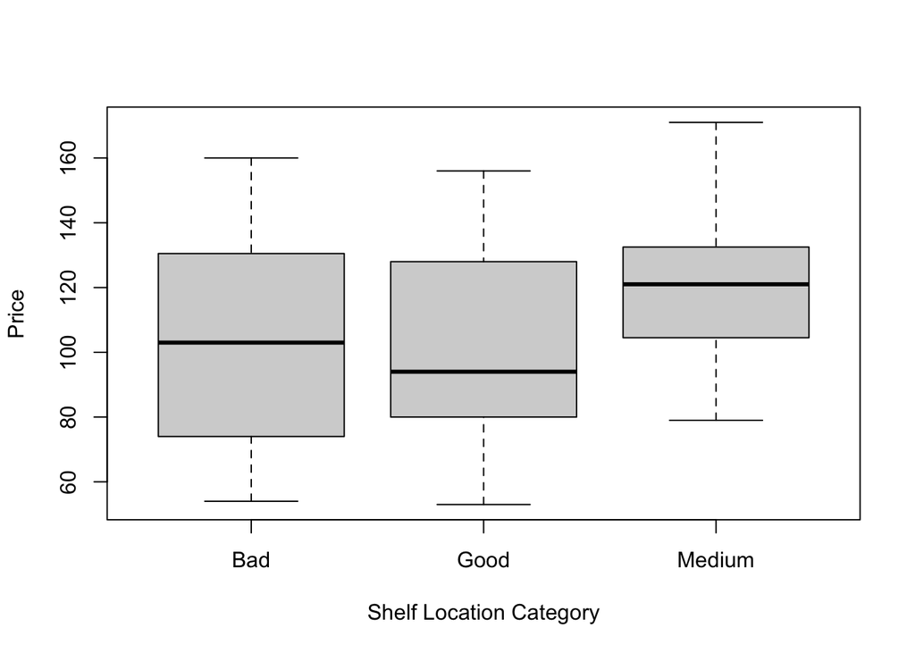

```r
boxplot(plotdat$Price~plotdat$PredShelveLocCat, xlab="Shelf Location Category", ylab="Price")
```

Good shelf location: Prices range from 60 to 155, but the median is the lowest among the three groups, around 95.

Medium shelf location: Prices range from 80 to 170, with the highest median at about 120. The distribution is narrower than in the “Bad” and “Good” categories, suggesting less variability.

Overall trend: Higher prices are more associated with the “Medium” shelf placements, lower prices are concentrated in “Good” shelves, and “Bad” shelves show a wide price spread with a median that sits between the other two.

##### Urban

```r
UrbanCat <- table(plotdat$Urban, plotdat$PredShelveLocCat)
UrbanCat
```

```
##
##       Bad Good Medium
##   No    1    6     35
##   Yes  10   11     57
```

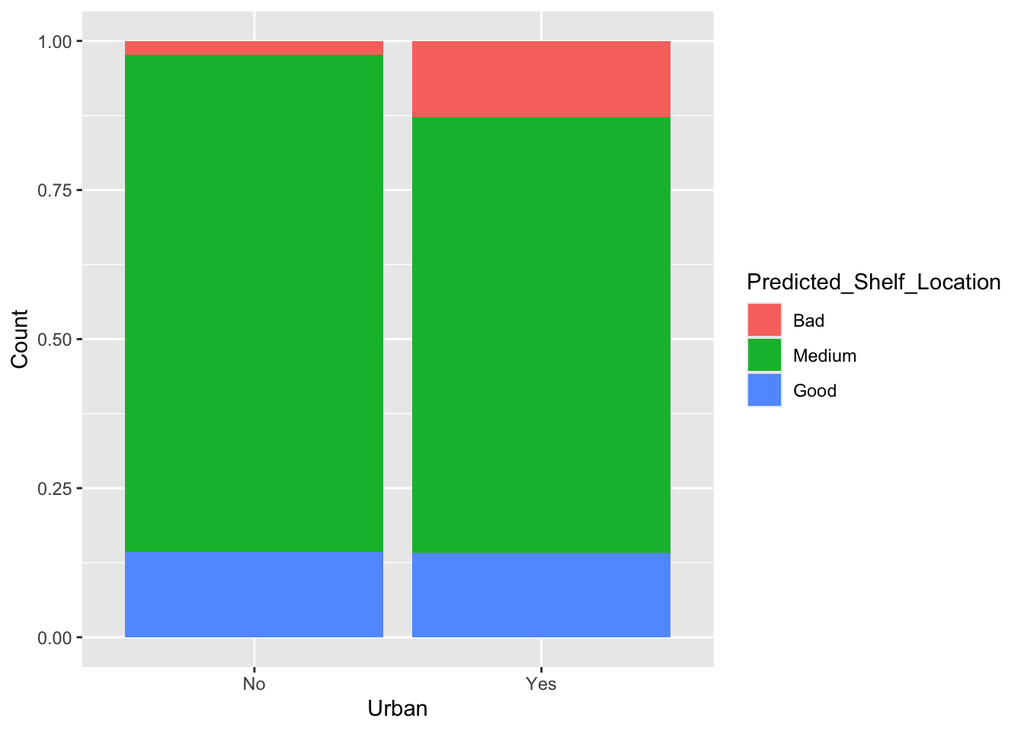

```r
UrbanDat <- matrix(c(UrbanCat, rep(levels(plotdat$PredShelveLocCat), each=2), rep(levels(plotdat$Urban), times=3)), nrow=6, ncol=3 )
UrbanDF <- data.frame(UrbanDat)
names(UrbanDF) <- c("Count", "Predicted_Shelf_Location", "Urban")

UrbanDF[,2]<- as.factor(UrbanDF[,2])
UrbanDF[,2] <- factor(UrbanDF[,2], levels(UrbanDF[,2])[c(1,3,2)])
UrbanDF[,3]<- as.factor(UrbanDF[,3])
UrbanDF$Count <- as.numeric(UrbanDF$Count)

ggplot(UrbanDF, aes(fill=Predicted_Shelf_Location, y=Count, x=Urban)) +
 geom_bar(position="Fill", stat="identity")
```

Overall, Medium shelf placements are the most common across both areas, Good placements remain consistent, and Bad placements appear more often in urban than in non-urban locations.

##### US

```r
USCat <- table(plotdat$US, plotdat$PredShelveLocCat)
USCat
```

```
##
##       Bad Good Medium
##   No    4    5     36
##   Yes   7   12     56
```

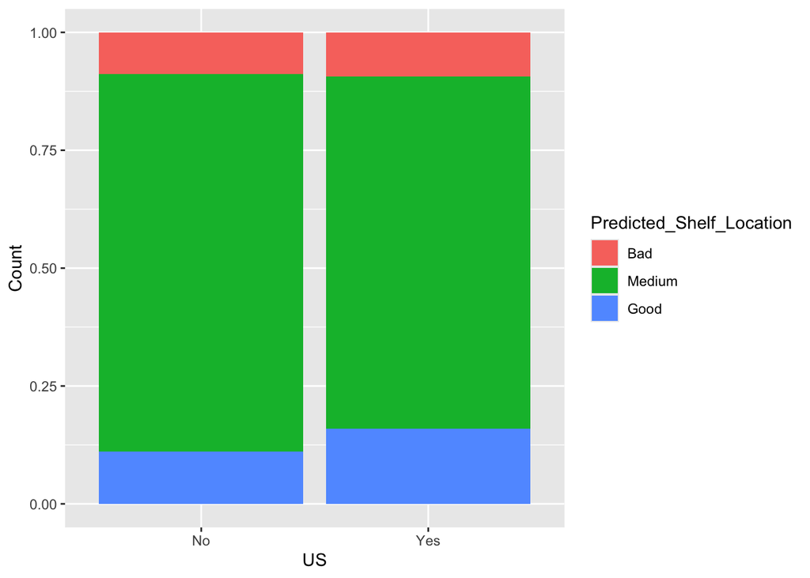

```r
USDat <- matrix(c(USCat, rep(levels(plotdat$PredShelveLocCat), each=2), rep(levels(plotdat$US), times=3)), nrow=6, ncol=3 )
USDF <- data.frame(USDat)
names(USDF) <- c("Count", "Predicted_Shelf_Location", "US")

USDF[,2]<- as.factor(USDF[,2])
USDF[,2] <- factor(USDF[,2], levels(USDF[,2])[c(1,3,2)])
USDF[,3]<- as.factor(USDF[,3])
USDF$Count <- as.numeric(USDF$Count)

ggplot(USDF, aes(fill=Predicted_Shelf_Location, y=Count, x=US)) +
 geom_bar(position="Fill", stat="identity")
```

#### Multinomial logistic model

```r
library(nnet)

mlr_mdl <- multinom(formula= ShelveLoc~Sales+Price+Urban+US, data=Carseats, subset=train)
summary_model <- summary(mlr_mdl)
```

```r
z_values <- summary_model$coefficients / summary_model$standard.errors
p_values <- 2 * (1 - pnorm(abs(z_values)))
p_values
```

```
##         (Intercept)        Sales        Price  UrbanYes        USYes
## Good   2.442491e-15 0.000000e+00 7.698597e-11 0.1379584 0.0009171772
## Medium 1.829555e-05 2.482075e-08 3.164169e-05 0.3696419 0.0915962724
```

```r
pred <- predict(mlr_mdl, Carseats[-train,])

mlr_mdl_tab<- table(pred=pred, true=Carseats$ShelveLoc[-train])

mlr_mdl_conf<-confusionMatrix(mlr_mdl_tab)
mlr_mdl_conf
```

```
## Confusion Matrix and Statistics
##
##         true
## pred     Bad Good Medium
##   Bad      8    0      4
##   Good     0   13      8
##   Medium  21   11     55
##
## Overall Statistics
##
##                Accuracy : 0.6333
##                  95% CI : (0.5405, 0.7194)
##     No Information Rate : 0.5583
##     P-Value [Acc > NIR] : 0.05827
##
##                   Kappa : 0.316
##
##  Mcnemar's Test P-Value : NA
##
## Statistics by Class:
##
##                      Class: Bad Class: Good Class: Medium
## Sensitivity             0.27586      0.5417        0.8209
## Specificity             0.95604      0.9167        0.3962
## Pos Pred Value          0.66667      0.6190        0.6322
## Neg Pred Value          0.80556      0.8889        0.6364
## Prevalence              0.24167      0.2000        0.5583
## Detection Rate          0.06667      0.1083        0.4583
## Detection Prevalence    0.10000      0.1750        0.7250
## Balanced Accuracy       0.61595      0.7292        0.6086
```

**Comment:** The multinomial logistic regression model has a higher overall accuracy of 63.33%, compared to 57.5% for the KNN model. This suggests that multinomial logistic regression is more effective at correctly classifying shelf locations overall. While the KNN model performs reasonably well, especially with a balanced accuracy of 64.58% for the Good shelf category, the multinomial model provides stronger overall accuracy for this task.

#### Model comparison

With k=16, the model achieved its highest overall accuracy of 57.5%. By category, the Good shelf location had the strongest balanced accuracy at 64.58%, reflecting a balance between sensitivity (37.5%) and specificity (91.67%). This indicates that although the model’s overall accuracy is only moderate, it is especially effective at classifying the Good category compared to Bad and Medium.